# Plantilla para el análisis exploratorio unidimensional

El fichero de datos DB_1.sav contiene, entre otras, las variables znac_def, zmortinf, zfertil, zinc_pob, ztasa_na, zurbana, zalfabet, zcaloria, zlog_pib, zpib_cap, zpoblac, zdensida, que son las variables estandarizadas de las originales de igual denominación sin la z inicial, y que respectivamente son los valores para cada país del mundo de:

## Variables

• Tasa Nacimientos/Defunciones (nac_def).

• Mortalidad infantil: muertes por 1000 nacimientos vivos (mortinf).

• Fertilidad: numero promedio de hijos (fertil).

• Aumento de la poblacion en % anual (inc_pob).

• Tasa de natalidad por 1.000 habitantes (tasa_na).

• Habitantes en ciudades en % (urbana).

• Personas Alfabetizadas en % (alfabet).

• Ingesta diaria de calorias (calorias).

• Log(10) de PIB_CAP (log_pib).

• Producto interior bruto per-capita (pib_cap).

• Poblacion en miles (poblac).

• Habitantes por Km2 (densidad).

El dataset contiene un total de 48 variables, listadas anteriormente solamente están 15 (de la 32 a la 46) de estas, concretamente son las variables estandarizadas.

Cargamos los datos a partir del fichero *DB_1.sav*.

Echamos un primer vistazo a los datos, observando directamente el dataframe en el que vienen, para ver si los datos efectivamente están estandarizados (datos numéricos, continuos, tanto negativos como positivos y entorno al 0), y para comprobar la existencia de *NA*s.

```
##      znac_def   zmortinf    zfertil   zinc_pob   ztasa_na    zurbana   zespvida
## 1  0.03868813 -0.1920453 -0.4011015 -0.2358004 -0.2364663 -0.1044391  0.4582045
## 2 -0.37384556  3.3006728  1.7539901  0.9332426  2.1905419 -1.5918355 -2.4741310
## 3 -1.03695529 -0.9404849 -1.1001922 -1.1042324 -1.2072696  1.1763745  0.8365704
## 4  1.47287936  0.2543924  1.6330948  1.2672549  0.9770378  0.8458419 -0.0147528
## 5 -0.46178485 -0.4388991 -0.4011015 -0.3193035 -0.4791671  1.2176910  0.4582045
## 6  0.29639437 -0.4021336 -0.1961050 -0.2358004 -0.2364663  0.4739928  0.4582045
##     zalfabet  zcaloría    zlog_pib   zpib_cap     zpoblac    zdensida
## 1  0.8593011        NA  0.08919672 -0.4413664 -0.27482369 -0.17376613
## 2 -2.1560126        NA -1.79026124 -0.8727045 -0.18554185 -0.26404219
## 3  0.9030013 1.2137014  1.32599590  1.8023633  0.22815340  0.03490475
## 4 -0.7139060 0.2116370  0.64683381  0.1220738 -0.20258037 -0.28964507
## 5  0.7282005 0.6325393  0.17850868 -0.3784018 -0.09421538 -0.28328135
## 6  0.8593011        NA  0.44698551 -0.1327166 -0.30004070 -0.11456872
##     zlog_pob    zlogden
## 1 -0.3741906  0.2412855
## 2  0.3022811 -0.6190089
## 3  1.2161251  0.9171441
## 4  0.2159396 -1.4390443
## 5  0.6362133 -1.1300927
## 6 -0.8343670  0.5072375
```

Vemos tanto la existencia de valores perdidos, y que las variables efectivamente están estandarizadas.

Vamos a ver si hay, donde, y cuantos *NA* hay en los datos

```
##          [,1]        [,2]
## znac_def    1 0.009174312
## zmortinf    0 0.000000000
## zfertil     2 0.018348624
## zinc_pob    0 0.000000000
## ztasa_na    0 0.000000000
## zurbana     1 0.009174312
## zespvida    0 0.000000000
## zalfabet    2 0.018348624
## zcaloría   34 0.311926606
## zlog_pib    0 0.000000000
## zpib_cap    0 0.000000000
## zpoblac     0 0.000000000
## zdensida    0 0.000000000
## zlog_pob    0 0.000000000
## zlogden     0 0.000000000
```

Vemos que apenas hay variables con datos faltantes, pero una de las variables (*zcalorías*) tiene un casi un tercio de sus registros faltantes, vamos a tratar este caso con mas atención.

```
##    znac_def    zmortinf     zfertil    zinc_pob    ztasa_na     zurbana
## -0.22369593 -0.77397271 -0.69086451 -0.59672889 -0.75665714  0.69235463
##    zespvida    zalfabet    zcaloría    zlog_pib    zpib_cap     zpoblac
##  0.77568669  0.68160023  1.00000000  0.84847603  0.75965027 -0.04188348
##    zdensida    zlog_pob     zlogden
##  0.06864342  0.05361848  0.03610921
```

Vemos que la variable que mejor se correlaciona con *zcalorías* es *zlog_pib*, de modo que vamos a hacer una prueba de homogeneidad de medias entre las dos poblaciones para discernir si los datos faltantes siguen un patrón no aleatorio

```
##
##  Welch Two Sample t-test
##
## data:  datos$zlog_pib[faltantes] and datos$zlog_pib[-faltantes]
## t = 2.0427, df = 85.872, p-value = 0.04414
## alternative hypothesis: true difference in means is not equal to 0
## 95 percent confidence interval:
##  0.009957689 0.732792674
## sample estimates:
##  mean of x  mean of y
##  0.2555334 -0.1158418
```

Tenemos una diferencia significativa entre las medias de ambas muestras, de modo que vamos a ver si esta diferencia se debe a outliers.

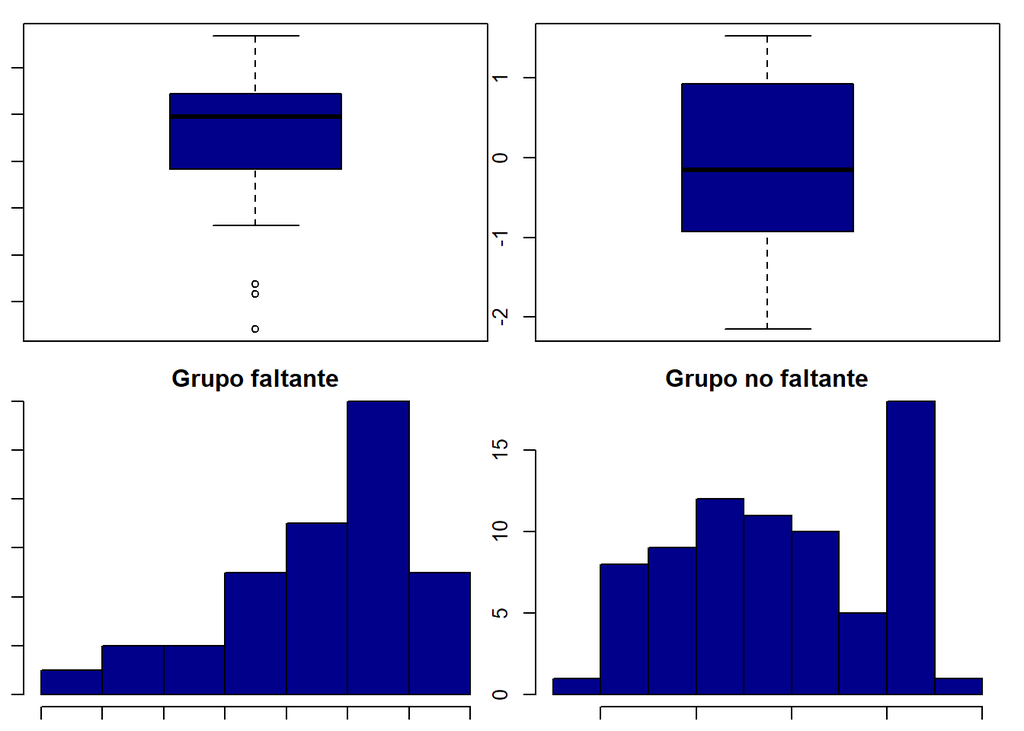

Como las distribuciones en los histogramas no son tan difernetes, y la media está muy condicionada por ese “gran bulto” que hay al rededor del 1, vamos a probar con la variable *zespvida*

```
##
##  Welch Two Sample t-test
##
## data:  datos$zespvida[faltantes] and datos$zespvida[-faltantes]
## t = 2.2942, df = 90.333, p-value = 0.0241
## alternative hypothesis: true difference in means is not equal to 0
## 95 percent confidence interval:
##  0.05459528 0.75970744
## sample estimates:
##  mean of x  mean of y
##  0.2801500 -0.1270013
```

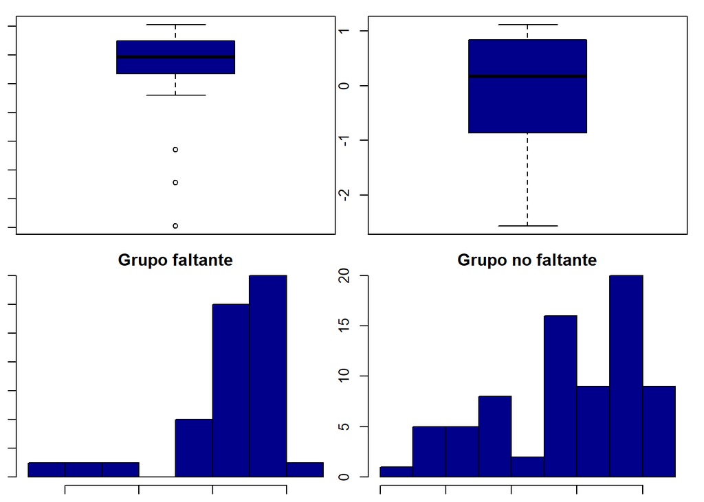

La situación es identifica a lo sucedido con *zlog_pib*, los faltantes tienen un mayor valor, y existe diferencia significativa entre las medias, de modo que deducimos que la ausencia de datos no es aleatoria.

Como se ha hablado en clase, se sustituirán los *NA*, con el debido aviso

El resto de variables con *NA* no tienen una cantidad a tener en cuenta (inferior al $5\%$).

Como se ha especificado, se intercambiarán los valores perdidos por la media (tan solo tenemos variables cuantitativas).

## Recodificación

En este caso no es necesaria.

# Exploración Univariante

## Exploración descriptiva

En este apartado iremos variable por variable obteniendo los resultados de aplicar diferentes medidas descriptivas, clásicas y resistentes, de centralidad, forma y dispersión.

Aplicamos la función para cada una de las variables:

**znac_def**

```
## $centralidad
## $centralidad$clasica
## $centralidad$clasica$media
## [1] -3.431724e-16
##
##
## $centralidad$resistente
##                   [,1]
## PMC         -0.1611276
## Trimedia    -0.2068798
## Centrimedia -0.1911137
##
##
## $dispersion
## $dispersion$clasica
## $dispersion$clasica$desviación_típica
## [1] 0.9953596
##
## $dispersion$clasica$Coef_varización
## [1] -2.900465e+15
##
## $dispersion$clasica$rango
## [1] -1.073155  5.080767
##
##
## $dispersion$resistente
##                               75%
## Rango Inter-Cuartílico  1.2287732
## MEDA                    0.5960857
## CVc                    -3.8130446
##
##
## $forma
## $forma$clasica
## $forma$clasica$skewness
## [1] 1.837301
##
## $forma$clasica$kurtosis
## [1] 5.66412
##
##
## $forma$resistente
##                                        25%
## Asimetría de Yule               -0.3622043
## Asimetría de Kelly              -0.3858871
## Asimetría de Kelly adimensional  1.5274674
```

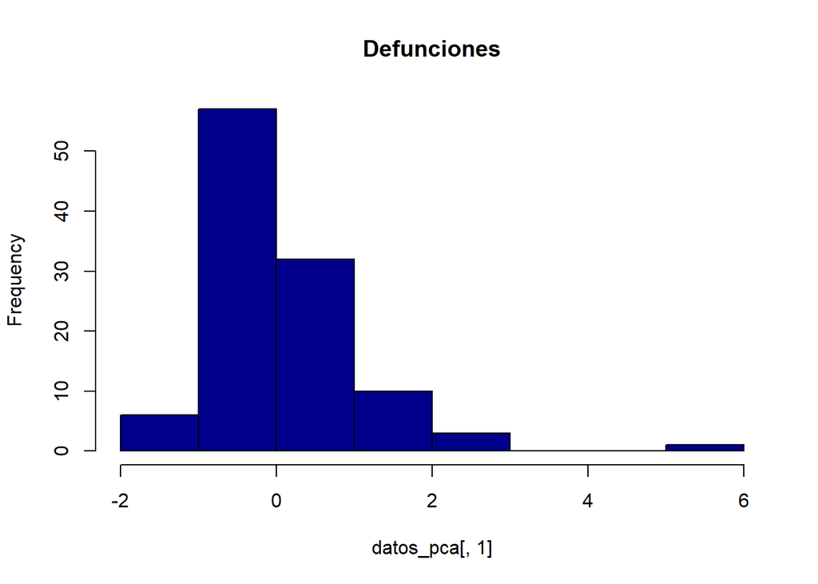

Las medidas resistentes de centralidad están ligeramente desplazadas hacia la izquierda. Esto sumado al rango, indica un amontonamiento de los valores en una región relativamente pequeña a la izquierda del $0$. Tenemos un valor del *MEDA* bastante inferior al de la desviación típica. En los estimadores de simetría, obtenemos que existe cierta asimetría, y el valor de *kurtosis* indica una gran acumulación de los datos.

Todas estas conclusiones se pueden corroborar en el histograma, donde además se puede apreciar el valor outlier que ha provocado la diferencia entre las medidas clásicas y las resistentes.

**zmortinf**

```
## $centralidad
## $centralidad$clasica
## $centralidad$clasica$media
## [1] 1.44736e-17
##
##
## $centralidad$resistente
##                   [,1]
## PMC         -0.1618451
## Trimedia    -0.2727980
## Centrimedia -0.2807382
##
##
## $dispersion
## $dispersion$clasica
## $dispersion$clasica$desviación_típica
## [1] 1
##
## $dispersion$clasica$Coef_varización
## [1] 6.90913e+16
##
## $dispersion$clasica$rango
## [1] -1.006137  3.300673
##
##
## $dispersion$resistente
##                               75%
## Rango Inter-Cuartílico  1.4102178
## MEDA                    0.5462296
## CVc                    -4.3566899
##
##
## $forma
## $forma$clasica
## $forma$clasica$skewness
## [1] 1.090495
##
## $forma$clasica$kurtosis
## [1] 0.3646868
##
##
## $forma$resistente
##                                        25%
## Asimetría de Yule               -0.5782548
## Asimetría de Kelly              -0.7928208
## Asimetría de Kelly adimensional  2.0659777
```

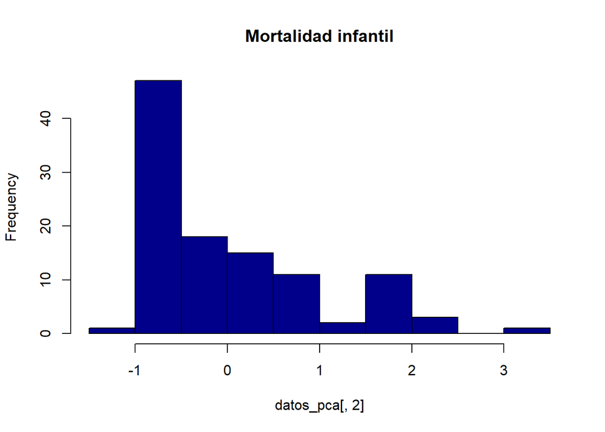

Se observa en este caso un fenómeno parecido, pero con un *kurtosis* que indica un menor amontonamiento, y un rango bastante inferior, y una asimetría mas pronunciada.

En el histograma observamos que la distribuían está mas aplanada que la anterior, pero su forma efectivamente es mas asimétrica

**zfertil**

```
## $centralidad
## $centralidad$clasica
## $centralidad$clasica$media
## [1] 7.122134e-16
##
##
## $centralidad$resistente
##                    [,1]
## PMC         -0.09097857
## Trimedia    -0.17245154
## Centrimedia -0.25545016
##
##
## $dispersion
## $dispersion$clasica
## $dispersion$clasica$desviación_típica
## [1] 0.9906975
##
## $dispersion$clasica$Coef_varización
## [1] 1.391012e+15
##
## $dispersion$clasica$rango
## [1] -1.189550  2.432056
##
##
## $dispersion$resistente
##                               75%
## Rango Inter-Cuartílico  1.5874090
## MEDA                    0.6622965
## CVc                    -8.7240821
##
##
## $forma
## $forma$clasica
## $forma$clasica$skewness
## [1] 0.6695007
##
## $forma$clasica$kurtosis
## [1] -0.9122207
##
##
## $forma$resistente
##                                        25%
## Asimetría de Yule               -0.6417102
## Asimetría de Kelly              -0.5634776
## Asimetría de Kelly adimensional  2.2190753
```

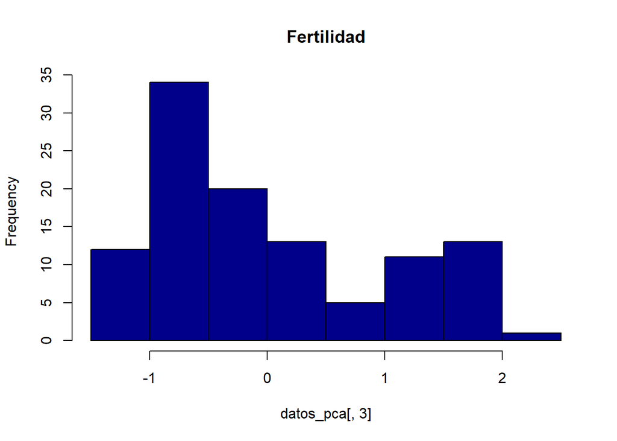

En esta ocasión obtenemos medidas dispares en los estimadores de centralidad resistentes (aunque siguen estando desplazados hacia la izquierda). Obtenemos un *MEDA* mayor que en los casos anteriores, y los estimadores de formas denotan una distribución mas simétrica, pero muy aplanada.

En el histograma se puede observar que lo anterior, es debido a que se tienen dos montículos de datos.

**zinc_pob**

```
## $centralidad
## $centralidad$clasica
## $centralidad$clasica$media
## [1] 5.528426e-16
##
##
## $centralidad$resistente
##                    [,1]
## PMC         -0.06879427
## Trimedia     0.01470880
## Centrimedia -0.02814561
##
##
## $dispersion
## $dispersion$clasica
## $dispersion$clasica$desviación_típica
## [1] 1
##
## $dispersion$clasica$Coef_varización
## [1] 1.808833e+15
##
## $dispersion$clasica$rango
## [1] -1.655353  2.970718
##
##
## $dispersion$resistente
##                                75%
## Rango Inter-Cuartílico   1.8036664
## MEDA                     0.8350307
## CVc                    -13.1091314
##
##
## $forma
## $forma$clasica
## $forma$clasica$skewness
## [1] 0.3239483
##
## $forma$clasica$kurtosis
## [1] -0.501509
##
##
## $forma$resistente
##                                        25%
## Asimetría de Yule               -1.7004680
## Asimetría de Kelly               0.1135642
## Asimetría de Kelly adimensional  1.1563183
```

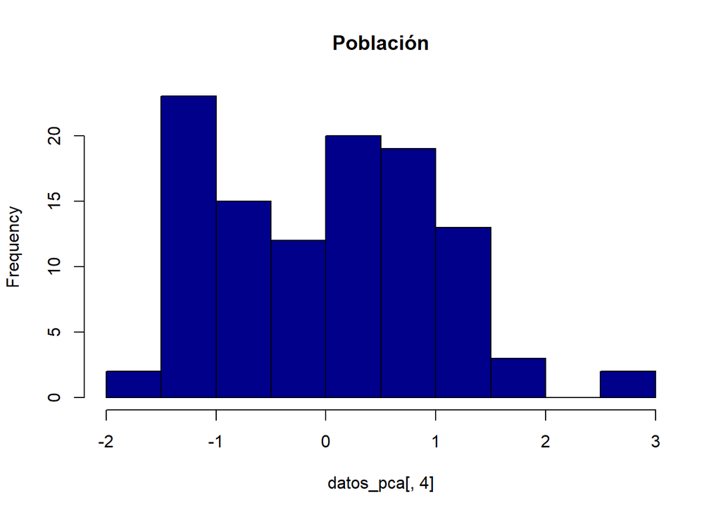

Esta distribución está considerablemente mas centrada que las anteriores, el *MEDA* se acerca bastante a la desviación típica, los estimadores de asimetría detecta una leve desviación, y un *kurtosis* que declara una distribución aplanada.

Una vez visto el histograma, se podría pensar que es una distribción normal un poco pocha, pero viendo las anteriores variables, parece algo sistemático en este dataset el desplazamiento hacia la derecha.

**ztasa_na**

```
## $centralidad
## $centralidad$clasica
## $centralidad$clasica$media
## [1] -4.975911e-16
##
##
## $centralidad$resistente
##                    [,1]
## PMC         -0.11511590
## Trimedia    -0.09489083
## Centrimedia -0.16298189
##
##
## $dispersion
## $dispersion$clasica
## $dispersion$clasica$desviación_típica
## [1] 1
##
## $dispersion$clasica$Coef_varización
## [1] -2.009682e+15
##
## $dispersion$clasica$rango
## [1] -1.288170  2.190542
##
##
## $dispersion$resistente
##                              75%
## Rango Inter-Cuartílico  1.698906
## MEDA                    0.889903
## CVc                    -7.379110
##
##
## $forma
## $forma$clasica
## $forma$clasica$skewness
## [1] 0.4455767
##
## $forma$clasica$kurtosis
## [1] -1.146535
##
##
## $forma$resistente
##                                        25%
## Asimetría de Yule                0.5417495
## Asimetría de Kelly              -0.2507909
## Asimetría de Kelly adimensional  3.3588469
```

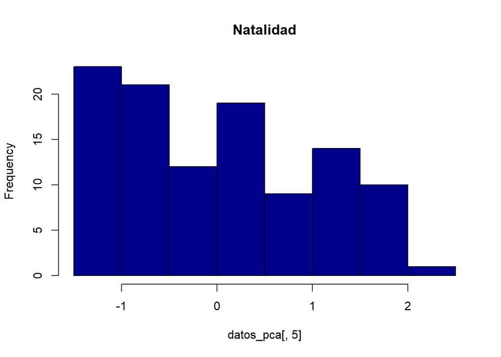

De nuevo, parece estar mas centralizada que sus compañeras, al igual que el *MEDA* se acerca a 1, y con unos valores no muy exagerados para los estadísticos de forma (a excepción de un *Kurtosis* muy poco pronunciado).

Vemos, coherente con el valo de *Kurtosis*, que la distribución está bastante aplanada, casi uniforme ligeramente descendente.

**zurbana**

```
## $centralidad
## $centralidad$clasica
## $centralidad$clasica$media
## [1] -6.095126e-16
##
##
## $centralidad$resistente
##                   [,1]
## PMC         0.06082717
## Trimedia    0.10214373
## Centrimedia 0.08462534
##
##
## $dispersion
## $dispersion$clasica
## $dispersion$clasica$desviación_típica
## [1] 0.9953596
##
## $dispersion$clasica$Coef_varización
## [1] -1.633042e+15
##
## $dispersion$clasica$rango
## [1] -2.128951  1.796123
##
##
## $dispersion$resistente
##                               75%
## Rango Inter-Cuartílico  1.4047632
## MEDA                    0.7023816
## CVc                    11.5471698
##
##
## $forma
## $forma$clasica
## $forma$clasica$skewness
## [1] -0.3095761
##
## $forma$clasica$kurtosis
## [1] -0.8175619
##
##
## $forma$resistente
##                                        25%
## Asimetría de Yule               -0.5760000
## Asimetría de Kelly               0.2685577
## Asimetría de Kelly adimensional  1.8720000
```

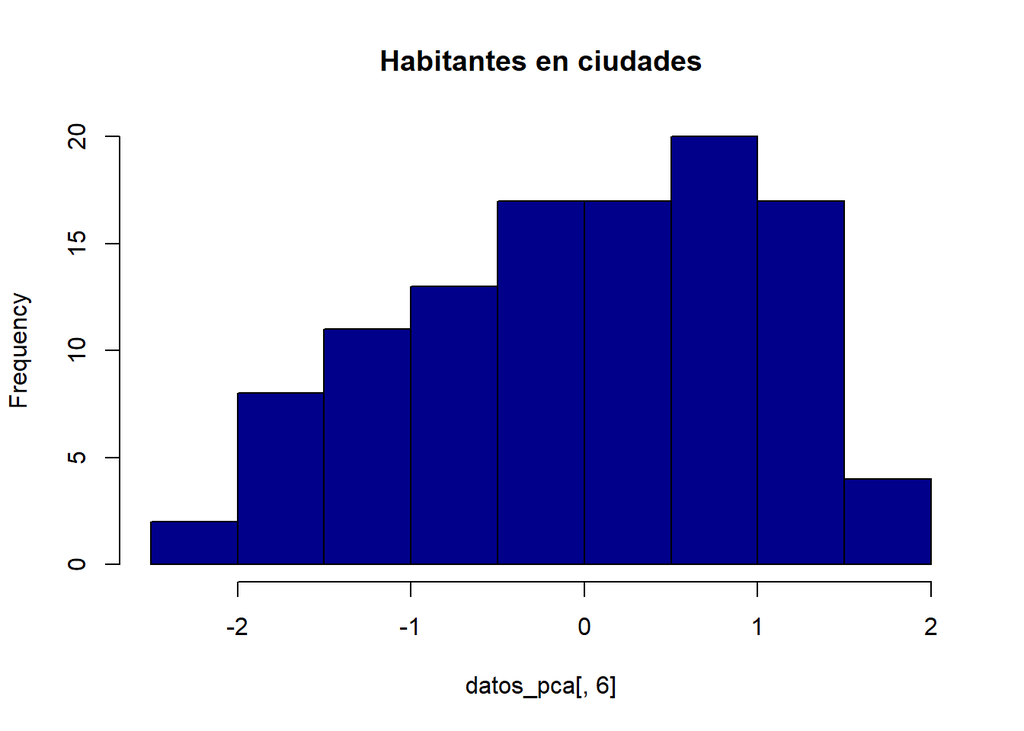

Acorde con lo poco notables que eran los valores de las medidas de forma, vemos que esta es la distribución que mas se acerca a una normal.

**zespvida**

```
## $centralidad
## $centralidad$clasica
## $centralidad$clasica$media
## [1] -3.866464e-16
##
##
## $centralidad$resistente
##                  [,1]
## PMC         0.2217259
## Trimedia    0.2926695
## Centrimedia 0.2883699
##
##
## $dispersion
## $dispersion$clasica
## $dispersion$clasica$desviación_típica
## [1] 1
##
## $dispersion$clasica$Coef_varización
## [1] -2.586343e+15
##
## $dispersion$clasica$rango
## [1] -2.568722  1.120345
##
##
## $dispersion$resistente
##                              75%
## Rango Inter-Cuartílico 1.0405062
## MEDA                   0.4729573
## CVc                    2.3463796
##
##
## $forma
## $forma$clasica
## $forma$clasica$skewness
## [1] -1.109125
##
## $forma$clasica$kurtosis
## [1] 0.2134595
##
##
## $forma$resistente
##                                        25%
## Asimetría de Yule               -0.3902148
## Asimetría de Kelly               0.7188952
## Asimetría de Kelly adimensional  1.9770883
```

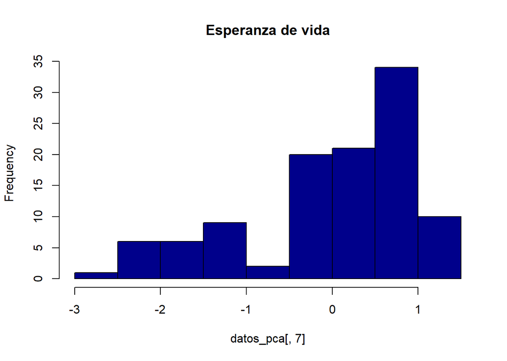

Las medidas de centralidad están desplazadas hacia la derecha, el papel de los rangos se ha intercambiado con respecto al de las anteriores variables. A pesar de lo grande que del rango, el *MEDA* apenas es de $0.473$. Se denota también una fuerte asimetría hacia la izquierda.

En el histograma vemos una forma bastante anormal para ser una distribución estandarizada.

**zalfabet**

```
## $centralidad
## $centralidad$clasica
## $centralidad$clasica$media
## [1] 1.1383e-15
##
##
## $centralidad$resistente
##                  [,1]
## PMC         0.1163977
## Trimedia    0.2474983
## Centrimedia 0.3211776
##
##
## $dispersion
## $dispersion$clasica
## $dispersion$clasica$desviación_típica
## [1] 0.9906975
##
## $dispersion$clasica$Coef_varización
## [1] 8.70331e+14
##
## $dispersion$clasica$rango
## [1] -2.6367148  0.9467015
##
##
## $dispersion$resistente
##                              75%
## Rango Inter-Cuartílico 1.4858067
## MEDA                   0.5244024
## CVc                    6.3824561
##
##
## $forma
## $forma$clasica
## $forma$clasica$skewness
## [1] -1.003272
##
## $forma$clasica$kurtosis
## [1] -0.1057951
##
##
## $forma$resistente
##                                        25%
## Asimetría de Yule               -0.6925566
## Asimetría de Kelly               0.6598730
## Asimetría de Kelly adimensional  1.7429342
```

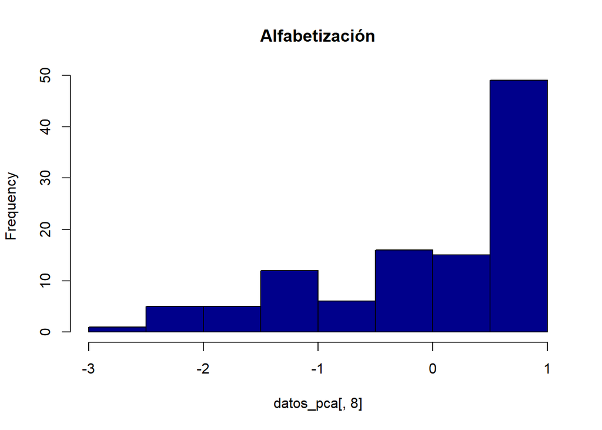

Los valores de centralidad salen bastante desplazados hacia la derecha. Se denota también una fuerte asimetría hacia la izquierda.

En el histograma se observa un fuerte comportamiento anómalo de la distribución.

**zcaloría** (variable con conclusiones sesgadas)

```
## $centralidad
## $centralidad$clasica
## $centralidad$clasica$media
## [1] 5.128813e-16
##
##
## $centralidad$resistente
##                    [,1]
## PMC         -0.07101919
## Trimedia    -0.03550960
## Centrimedia -0.04265533
##
##
## $dispersion
## $dispersion$clasica
## $dispersion$clasica$desviación_típica
## [1] 0.8277591
##
## $dispersion$clasica$Coef_varización
## [1] 1.613939e+15
##
## $dispersion$clasica$rango
## [1] -1.914008  1.886441
##
##
## $dispersion$resistente
##                              75%
## Rango Inter-Cuartílico  1.192263
## MEDA                    0.654823
## CVc                    -8.393949
##
##
## $forma
## $forma$clasica
## $forma$clasica$skewness
## [1] 0.2041585
##
## $forma$clasica$kurtosis
## [1] -0.3550579
##
##
## $forma$resistente
##                                           25%
## Asimetría de Yule               -1.384746e+14
## Asimetría de Kelly              -1.110783e-01
## Asimetría de Kelly adimensional -2.165826e+14
```

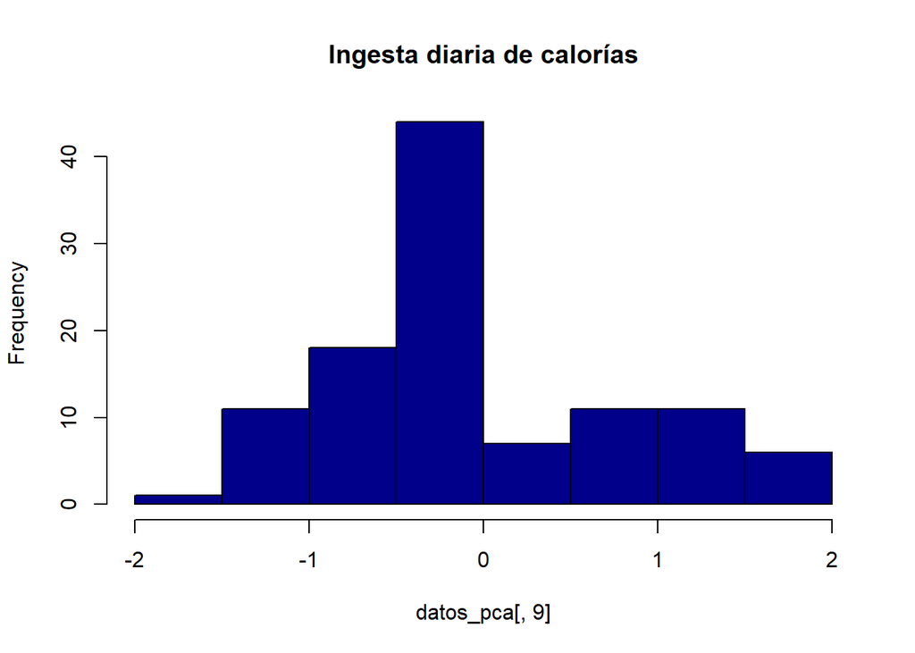

La propia desviación típica (supuesta 1 para variables estandarizadas) se ha visto fuertemente influenciada por la cantidad de valores que se han sustituido por la media. Aun así, el rango es el mas normal observado. Los coeficientes de formas adimensionales dan valores irreales, posiblemente causado por la correncción en los datos.

En el histograma se puede ver como efectivamente casi un tercio de los datos se cambiaron por la media.

**zlog_pib**

```
## $centralidad
## $centralidad$clasica
## $centralidad$clasica$media
## [1] -2.51638e-15
##
##
## $centralidad$resistente
##                   [,1]
## PMC         0.02380223
## Trimedia    0.05591531
## Centrimedia 0.06278398
##
##
## $dispersion
## $dispersion$clasica
## $dispersion$clasica$desviación_típica
## [1] 1
##
## $dispersion$clasica$Coef_varización
## [1] -3.973963e+14
##
## $dispersion$clasica$rango
## [1] -2.153768  1.530143
##
##
## $dispersion$resistente
##                               75%
## Rango Inter-Cuartílico  1.4081752
## MEDA                    0.7448956
## CVc                    29.5807371
##
##
## $forma
## $forma$clasica
## $forma$clasica$skewness
## [1] -0.2432049
##
## $forma$clasica$kurtosis
## [1] -1.048084
##
##
## $forma$resistente
##                                        25%
## Asimetría de Yule               -0.7296073
## Asimetría de Kelly               0.1641050
## Asimetría de Kelly adimensional  1.8642284
```

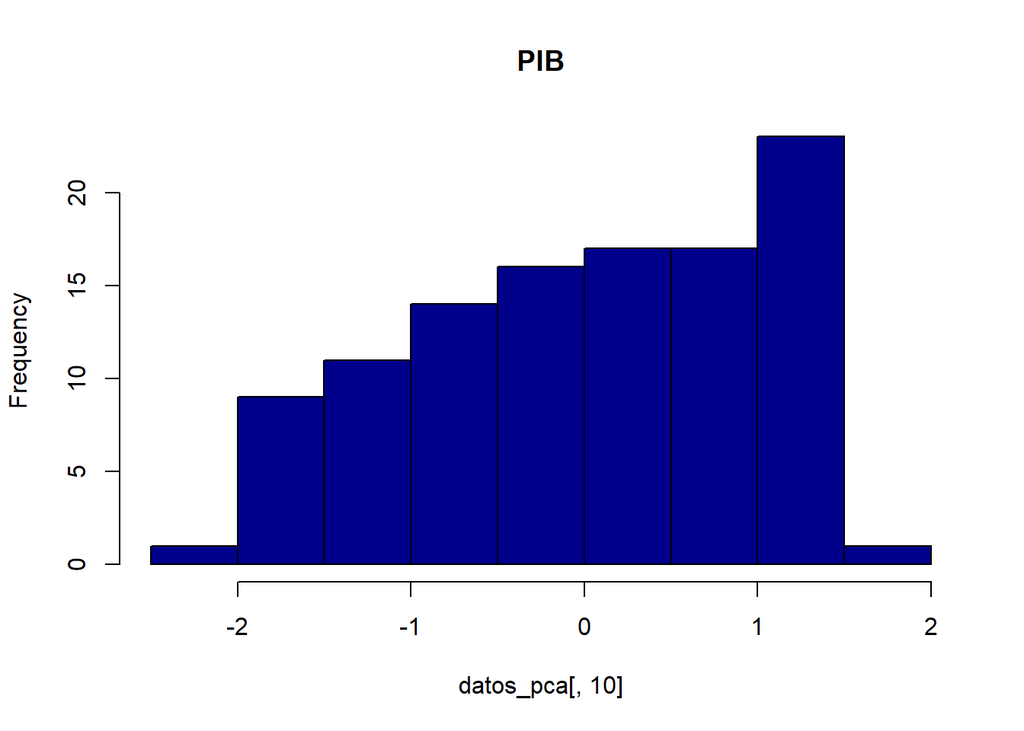

Para esta variable tenemos valores bastante estandar, a excepción de un *CVc* anormalmente grande, y una *kurtosis* que indica una distribución bastante aplanada.

Vemos en el histograma como efectuvamente es una distribución plana, pero que podría se una normal un tanto pocha.

**zpib_cap**

```
## $centralidad
## $centralidad$clasica
## $centralidad$clasica$media
## [1] -3.930482e-17
##
##
## $centralidad$resistente
##                   [,1]
## PMC         -0.2510066
## Trimedia    -0.3465723
## Centrimedia -0.3647630
##
##
## $dispersion
## $dispersion$clasica
## $dispersion$clasica$desviación_típica
## [1] 1
##
## $dispersion$clasica$Coef_varización
## [1] -2.544218e+16
##
## $dispersion$clasica$rango
## [1] -0.8855134  2.7182815
##
##
## $dispersion$resistente
##                               75%
## Rango Inter-Cuartílico  0.9980191
## MEDA                    0.4040226
## CVc                    -1.9880335
##
##
## $forma
## $forma$clasica
## $forma$clasica$skewness
## [1] 1.14565
##
## $forma$clasica$kurtosis
## [1] -0.02815874
##
##
## $forma$resistente
##                                        25%
## Asimetría de Yule               -0.4322890
## Asimetría de Kelly              -0.8974456
## Asimetría de Kelly adimensional  2.0297861
```

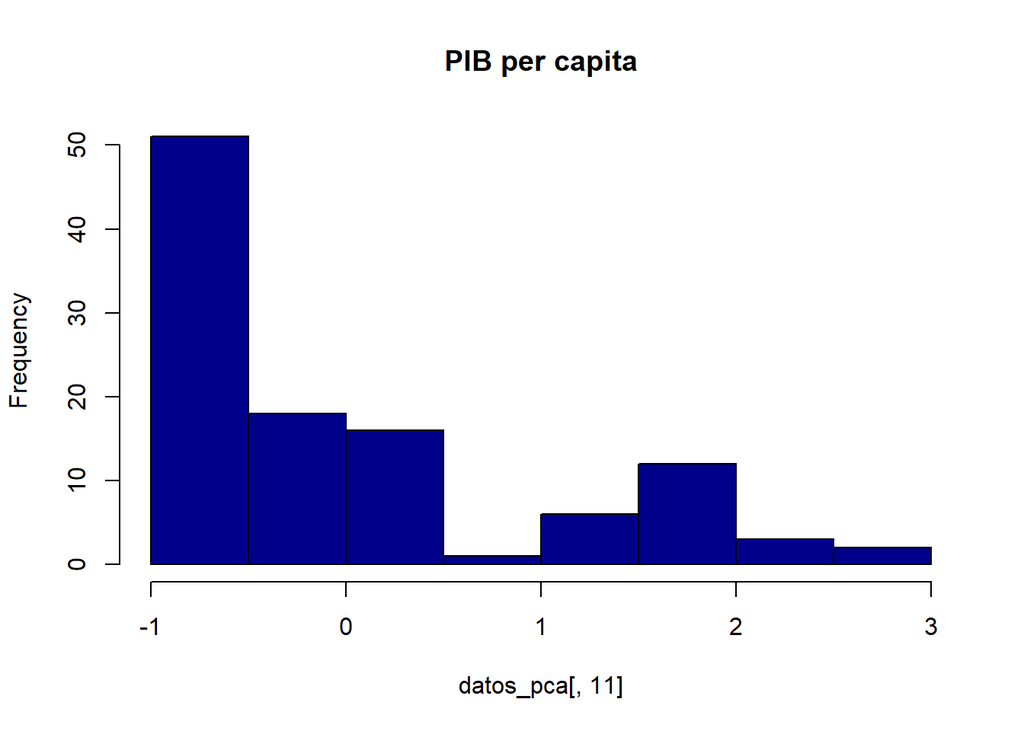

Tenemos medidas de centralidad desplazadas hacia la izquierda, volvemos a los rangos desplazados hacia a derecha, un rango intercuartílico ligeramente inferior a los vistos anteriormente, y fuertes desviaciones de la simetría.

El histograma de nuevo es de una distribución que se aleja bastante de una normal.

**zpoblac**

```
## $centralidad
## $centralidad$clasica
## $centralidad$clasica$media
## [1] -1.274783e-17
##
##
## $centralidad$resistente
##                   [,1]
## PMC         -0.1865642
## Trimedia    -0.2204708
## Centrimedia -0.2331518
##
##
## $dispersion
## $dispersion$clasica
## $dispersion$clasica$desviación_típica
## [1] 1
##
## $dispersion$clasica$Coef_varización
## [1] -7.844472e+16
##
## $dispersion$clasica$rango
## [1] -0.323513  7.888672
##
##
## $dispersion$resistente
##                               75%
## Rango Inter-Cuartílico  0.2078699
## MEDA                    0.0517971
## CVc                    -0.5571004
##
##
## $forma
## $forma$clasica
## $forma$clasica$skewness
## [1] 6.592336
##
## $forma$clasica$kurtosis
## [1] 46.65097
##
##
## $forma$resistente
##                                        25%
## Asimetría de Yule               -0.2665854
## Asimetría de Kelly              -0.2225231
## Asimetría de Kelly adimensional  0.8747751
```

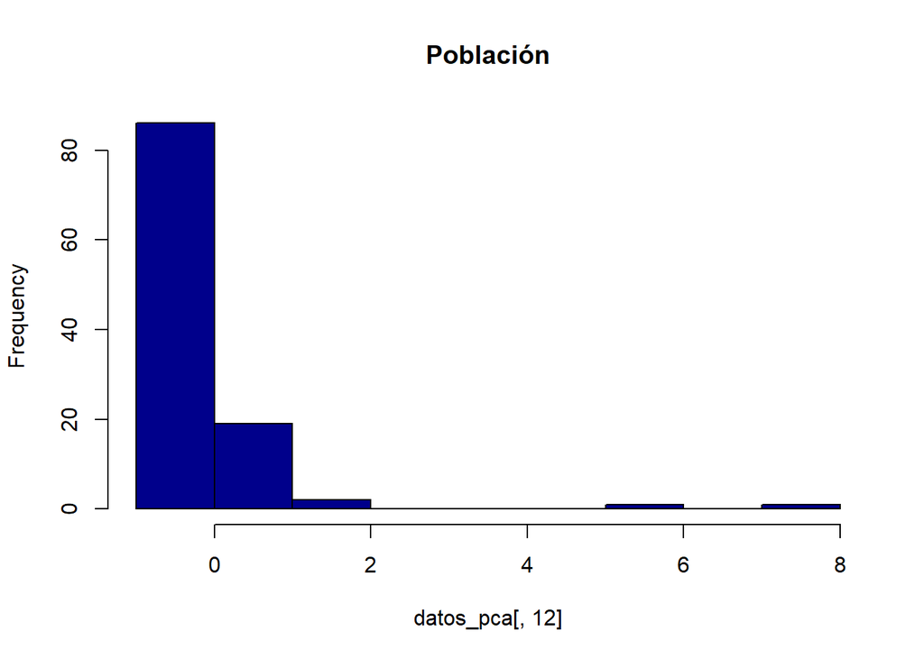

El valor medio resistente está ligeramente desplazado hacia la izquierda. Tenemos un rango intercuartílico muy anormalmente pequeño, al igual que el *MEDA*. Las diferencias entre los valores de los estadísticos de forma clasicos y resistentes indican una fuerte presencia de valores outliers.

Como se puede apreciar en el histograma, lo anterior es causado por unos valores outliers exagerados, las conclusiones para esta variable son inútiles teniendo en cuenta que los datos han pasado por una estandarización, pues esos valores outliers han condicionado la forma de toda la distribución (pues la estandarización fuerza la media y la varianza, es por eso que la inmensa mayoria de la variabilidad se ha ido para representar dichos outliers, y casi toda la distribución está a la izquierda para conseguir que la media sea $0$)

**zdensida**

```
## $centralidad
## $centralidad$clasica
## $centralidad$clasica$media
## [1] 1.780479e-17
##
##
## $centralidad$resistente
##                   [,1]
## PMC         -0.1863456
## Trimedia    -0.1963351
## Centrimedia -0.1980873
##
##
## $dispersion
## $dispersion$clasica
## $dispersion$clasica$desviación_típica
## [1] 1
##
## $dispersion$clasica$Coef_varización
## [1] 5.616467e+16
##
## $dispersion$clasica$rango
## [1] -0.2976367  7.8297242
##
##
## $dispersion$resistente
##                                75%
## Rango Inter-Cuartílico  0.14355373
## MEDA                    0.06659709
## CVc                    -0.38518146
##
##
## $forma
## $forma$clasica
## $forma$clasica$skewness
## [1] 6.886866
##
## $forma$clasica$kurtosis
## [1] 49.07625
##
##
## $forma$resistente
##                                         25%
## Asimetría de Yule               -0.09683342
## Asimetría de Kelly              -0.14530005
## Asimetría de Kelly adimensional  0.70423000
```

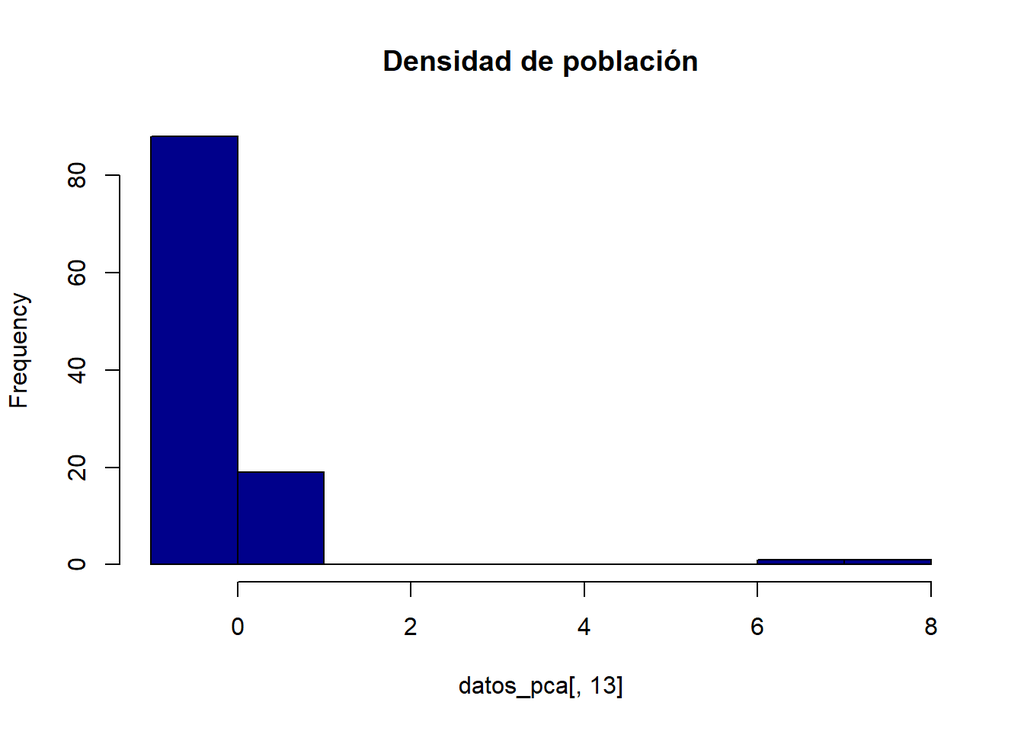

Sucede lo mismo que con la variable anterior.

**zlog_pob**

```
## $centralidad
## $centralidad$clasica
## $centralidad$clasica$media
## [1] 1.998978e-15
##
##
## $centralidad$resistente
##                    [,1]
## PMC          0.02368995
## Trimedia    -0.06228013
## Centrimedia -0.07512993
##
##
## $dispersion
## $dispersion$clasica
## $dispersion$clasica$desviación_típica
## [1] 1
##
## $dispersion$clasica$Coef_varización
## [1] 5.002556e+14
##
## $dispersion$clasica$rango
## [1] -2.607569  3.006970
##
##
## $dispersion$resistente
##                               75%
## Rango Inter-Cuartílico  1.2900163
## MEDA                    0.6622452
## CVc                    27.2270778
##
##
## $forma
## $forma$clasica
## $forma$clasica$skewness
## [1] 0.2497055
##
## $forma$clasica$kurtosis
## [1] 0.5836595
##
##
## $forma$resistente
##                                        25%
## Asimetría de Yule               -1.1597971
## Asimetría de Kelly              -0.2523425
## Asimetría de Kelly adimensional  1.7021394
```

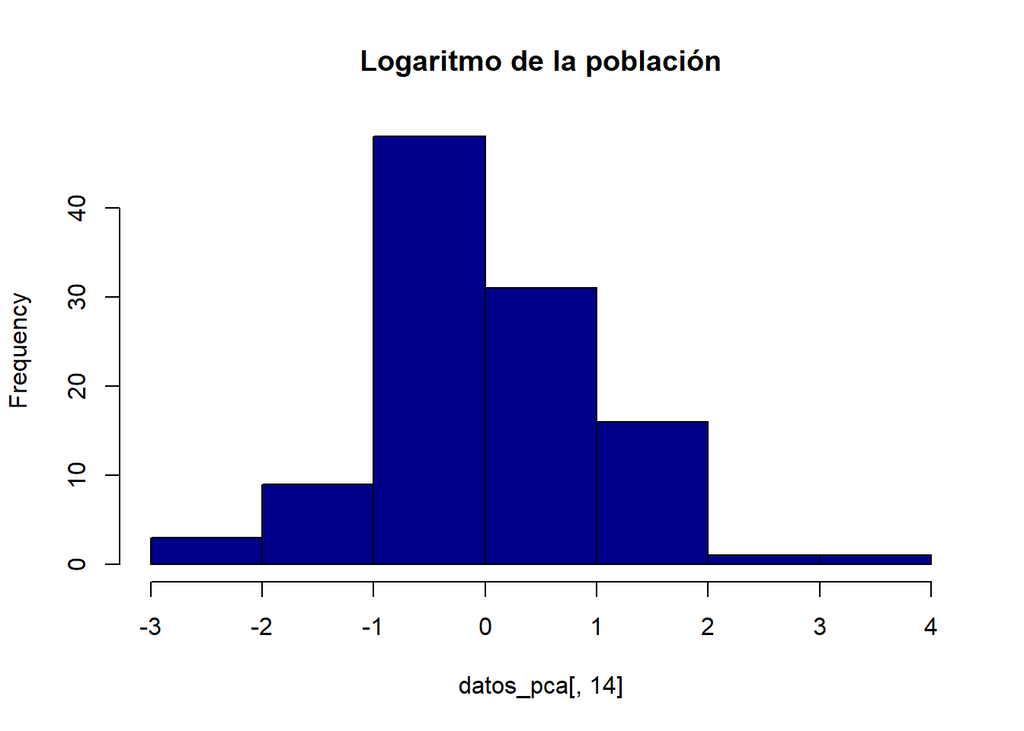

A excepción del coeficiente de asimetría de Yule, todos los valores son bastante acordes con una normal.

Parece acorde con una normal, a excepión del largo que tiene.

**zlogden**

```
## $centralidad
## $centralidad$clasica
## $centralidad$clasica$media
## [1] -6.255538e-16
##
##
## $centralidad$resistente
##                     [,1]
## PMC         -0.004211121
## Trimedia     0.015667051
## Centrimedia  0.034296923
##
##
## $dispersion
## $dispersion$clasica
## $dispersion$clasica$desviación_típica
## [1] 1
##
## $dispersion$clasica$Coef_varización
## [1] -1.598583e+15
##
## $dispersion$clasica$rango
## [1] -2.280426  3.135969
##
##
## $dispersion$resistente
##                                 75%
## Rango Inter-Cuartílico    1.0228973
## MEDA                      0.5047659
## CVc                    -121.4518862
##
##
## $forma
## $forma$clasica
## $forma$clasica$skewness
## [1] 0.06633855
##
## $forma$clasica$kurtosis
## [1] 0.888568
##
##
## $forma$resistente
##                                        25%
## Asimetría de Yule               -1.1184722
## Asimetría de Kelly               0.1008639
## Asimetría de Kelly adimensional  2.8376210
```

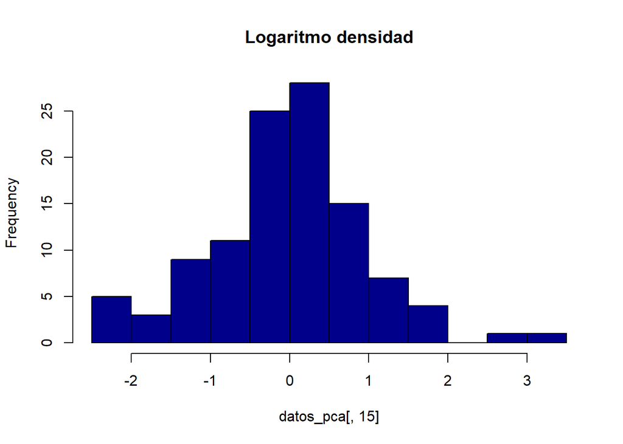

A excepción del *CVc* mas elevado que se ha visto, los valores son bastante normales.

El histograma denota una distribución bastante normal, a excepción de dos mini montículos en los extremos.

**NOTAR**: el hecho de que algunas de las variables estén desplazadas hacia la derecha, o que los outliers sean en esta dirección, es debido a que estas son estandarizaciones de variables positivas, en una variable positiva el valor mas extremo inferior como mucho es $0$.

Las que si tienen extensión hacia la izquierda, es debido a que no hay un gran porcentaje de la población que se acerque al extremo inferior, entonces el $0$ realmente si acaba siendo un valor “extremo” para estas variables.

También notar que el *CVc* toma valores bastante “sin sentido” debido a que esta medida no tiene mucho sentido en variables que toman valores positivos y negativos, en el caso de la variable 15 ese valor es devido a que $Q_1 \approx -Q_3$

**TAMBIEN**: aunque en los comentarios, hago continuas referencias a las variables anteriormente analizadas, es para crear un marco de referencia dentro del dataset, no para comparar unas variables con otras.

## Exploración Gráfica

Procedemos con los diagramas de cajas y bigotes, para una detección primaria de outliers univariantes.

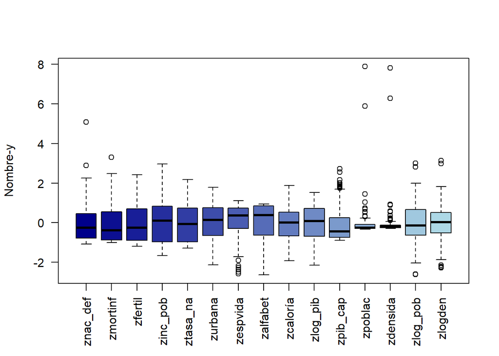

Se puede observar que la mayoría de gráficos se asemejan en cierto modo a una normal, con los 5 primeros estando ligeramente desplazados, los 15 14 y 9 10 siendo los que mas normales aparentan ser, y con 13 y 12 (*zpoblac* y *zdensidad*) con una gran concentración al 0, y una gran cantidad de outliers en la cola superior

(El tratamiento que tendremos con estos valores outliers será el mismo que en la práctica anterior, aunque en lo personal, no creo que sea buena idea eliminar los outliers de las variables *zpoblac* y *zdensidad*; me explico:

Cuando consideramos que un valor es un outlier, es por que suponemos que no es representativo de la población para el tamaño de muestra que tenemos; en este caso, los outliers los estamos considerando en base a un diagrama boxplot, este indica valores outliers basándose en la hipótesis de estar en una distribución normal, en el caso de *zpoblac* y *zdensidad*, es claro que no proviene de una normal, luego este “análisis outlier” no es valido **directamente a estas variables**, para el resto se podría “pasar la mano” o hacer contrastes de normalidad.)

A continuación vamos a observar (de nuevo) la forma de las distribuciones de las variables mediante sus histogramas

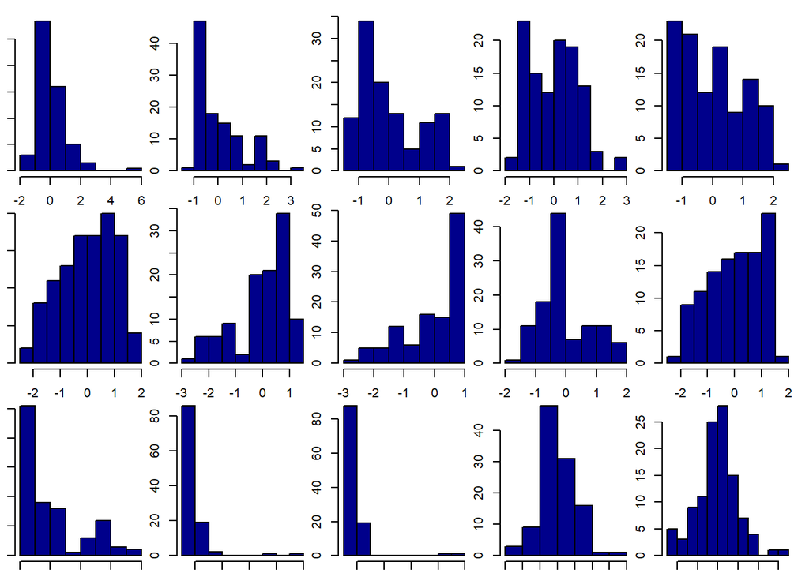

Observamos que realmente pocas de las variables realmente se podrían considerar normales (la 1 y 7 por los pelos, la 6, 9, 14 y 15), pero como no son casos tan extremos como 12 y 13, se eliminarán los outliers de todas menos de estas dos.

### Tratamiento de outliers

Los valores outlier comentados anteriormente (según si el diagrama boxplot los consideraba outliers o no, y contando con las excepciones comentadas) serán intercambiados por la media.

Una vez tratados los outliers, vemos de nuevo los gráficos boxplot.

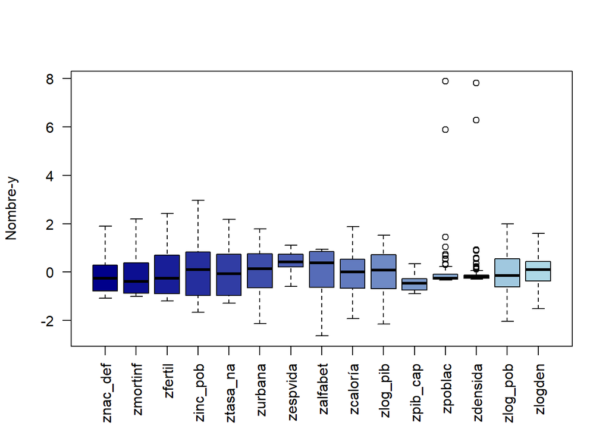

Efectivamente, hemos perdido dichos valores anómalos.

### Normalidad

Para poder aplicar ciertas técnicas estadísticas, es importante saber si estamos tratando con variables normales, para ello usaremos el método gráfico *qq-plot*.

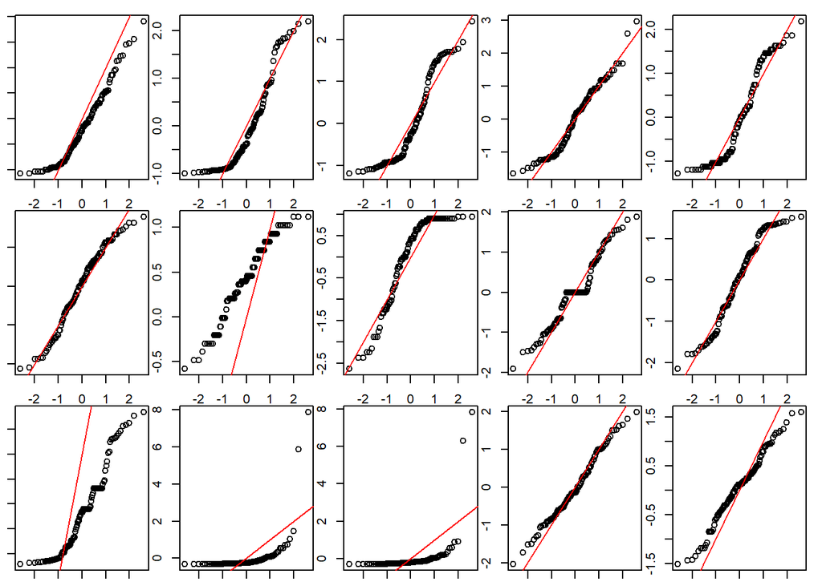

Vemos como las variables que mas se acercan a la normalidad son la 4, 6, la 10, la 14 y la 15. No tan cerca están las variables 1, 2, 3, 5, 7, 8, 11, y con desviaciones totales encontramos las variables 12 y 13 (estas desviaciones pueden estar debidas a sus numerosos valores outliers no tratados).

En este caso no tomaremos medidas para obtener normalidad en los datos.

### Homocedasticidad

La homocedasticidad se debe comparar dentro de una misma variable, para dos o mas grupos diferenciados; en el caso de este dataset, podemos comprobar si existe homocedasticidad entre los grupos definidos por la religión Católica y Musulmana (los dos grupos mas frecuentes, puesto que de los otros hay tan pocos que podrían dar conclusiones equivocadas) que profesa cada país.

```
##                                      znac_def
##    "Existe homocedasticidad entre los grupos"
##                                      zmortinf
##    "Existe homocedasticidad entre los grupos"
##                                       zfertil
##    "Existe homocedasticidad entre los grupos"
##                                      zinc_pob
##    "Existe homocedasticidad entre los grupos"
##                                      ztasa_na
##    "Existe homocedasticidad entre los grupos"
##                                       zurbana
##    "Existe homocedasticidad entre los grupos"
##                                      zespvida
## "No existe homocedasticidad entre los grupos"
##                                      zalfabet
## "No existe homocedasticidad entre los grupos"
##                                      zcaloría
## "No existe homocedasticidad entre los grupos"
##                                      zlog_pib
##    "Existe homocedasticidad entre los grupos"
##                                      zpib_cap
##    "Existe homocedasticidad entre los grupos"
##                                       zpoblac
## "No existe homocedasticidad entre los grupos"
##                                      zdensida
##    "Existe homocedasticidad entre los grupos"
##                                      zlog_pob
## "No existe homocedasticidad entre los grupos"
##                                       zlogden
##    "Existe homocedasticidad entre los grupos"
```

## Exploración Descriptiva

A continuación vamos a sacar los principales estadísticos descriptivos ahora que tenemos los datos transformados.

**Originales**

```
##     znac_def          zmortinf          zfertil           zinc_pob
##  Min.   :-1.0732   Min.   :-1.0061   Min.   :-1.1895   Min.   :-1.65535
##  1st Qu.:-0.7821   1st Qu.:-0.8670   1st Qu.:-0.8847   1st Qu.:-0.97063
##  Median :-0.2526   Median :-0.3838   Median :-0.2697   Median : 0.09821
##  Mean   : 0.0000   Mean   : 0.0000   Mean   : 0.0000   Mean   : 0.00000
##  3rd Qu.: 0.4572   3rd Qu.: 0.5433   3rd Qu.: 0.7553   3rd Qu.: 0.83304
##  Max.   : 5.0808   Max.   : 3.3007   Max.   : 2.4321   Max.   : 2.97072
##  NA's   :1                           NA's   :2
##     ztasa_na           zurbana           zespvida          zalfabet
##  Min.   :-1.28817   Min.   :-2.1290   Min.   :-2.5687   Min.   :-2.6367
##  1st Qu.:-0.96457   1st Qu.:-0.6519   1st Qu.:-0.2985   1st Qu.:-0.6702
##  Median :-0.07467   Median : 0.1435   Median : 0.3636   Median : 0.4223
##  Mean   : 0.00000   Mean   : 0.0000   Mean   : 0.0000   Mean   : 0.0000
##  3rd Qu.: 0.73434   3rd Qu.: 0.7632   3rd Qu.: 0.7420   3rd Qu.: 0.8593
##  Max.   : 2.19054   Max.   : 1.7961   Max.   : 1.1203   Max.   : 0.9467
##                     NA's   :1                           NA's   :2
##     zcaloría          zlog_pib           zpib_cap          zpoblac
##  Min.   :-1.9140   Min.   :-2.15377   Min.   :-0.8855   Min.   :-0.32351
##  1st Qu.:-0.8767   1st Qu.:-0.68029   1st Qu.:-0.7500   1st Qu.:-0.29050
##  Median :-0.1776   Median : 0.08803   Median :-0.4421   Median :-0.25438
##  Mean   : 0.0000   Mean   : 0.00000   Mean   : 0.0000   Mean   : 0.00000
##  3rd Qu.: 0.8315   3rd Qu.: 0.72789   3rd Qu.: 0.2480   3rd Qu.:-0.08263
##  Max.   : 1.8864   Max.   : 1.53014   Max.   : 2.7183   Max.   : 7.88867
##  NA's   :34
##     zdensida          zlog_pob          zlogden
##  Min.   :-0.2976   Min.   :-2.6076   Min.   :-2.28043
##  1st Qu.:-0.2581   1st Qu.:-0.6213   1st Qu.:-0.51566
##  Median :-0.2063   Median :-0.1483   Median : 0.03555
##  Mean   : 0.0000   Mean   : 0.0000   Mean   : 0.00000
##  3rd Qu.:-0.1146   3rd Qu.: 0.6687   3rd Qu.: 0.50724
##  Max.   : 7.8297   Max.   : 3.0070   Max.   : 3.13597
##
```

**Tratados**

```
##     znac_def          zmortinf           zfertil           zinc_pob
##  Min.   :-1.0732   Min.   :-1.00614   Min.   :-1.1895   Min.   :-1.65535
##  1st Qu.:-0.7755   1st Qu.:-0.86695   1st Qu.:-0.8847   1st Qu.:-0.97063
##  Median :-0.2526   Median :-0.38375   Median :-0.2539   Median : 0.09821
##  Mean   :-0.1557   Mean   :-0.05387   Mean   : 0.0000   Mean   : 0.00000
##  3rd Qu.: 0.2964   3rd Qu.: 0.38570   3rd Qu.: 0.7027   3rd Qu.: 0.83304
##  Max.   : 1.9043   Max.   : 2.19771   Max.   : 2.4321   Max.   : 2.97072
##     ztasa_na           zurbana           zespvida          zalfabet
##  Min.   :-1.28817   Min.   :-2.1290   Min.   :-0.5823   Min.   :-2.6367
##  1st Qu.:-0.96457   1st Qu.:-0.6416   1st Qu.: 0.2056   1st Qu.:-0.6265
##  Median :-0.07467   Median : 0.1435   Median : 0.4210   Median : 0.3786
##  Mean   : 0.00000   Mean   : 0.0000   Mean   : 0.4210   Mean   : 0.0000
##  3rd Qu.: 0.73434   3rd Qu.: 0.7632   3rd Qu.: 0.7420   3rd Qu.: 0.8593
##  Max.   : 2.19054   Max.   : 1.7961   Max.   : 1.1203   Max.   : 0.9467
##     zcaloría          zlog_pib           zpib_cap          zpoblac
##  Min.   :-1.9140   Min.   :-2.15377   Min.   :-0.8855   Min.   :-0.32351
##  1st Qu.:-0.6672   1st Qu.:-0.68029   1st Qu.:-0.7500   1st Qu.:-0.29050
##  Median : 0.0000   Median : 0.08803   Median :-0.4656   Median :-0.25438
##  Mean   : 0.0000   Mean   : 0.00000   Mean   :-0.4656   Mean   : 0.00000
##  3rd Qu.: 0.5251   3rd Qu.: 0.72789   3rd Qu.:-0.2737   3rd Qu.:-0.08263
##  Max.   : 1.8864   Max.   : 1.53014   Max.   : 0.3395   Max.   : 7.88867
##     zdensida          zlog_pob            zlogden
##  Min.   :-0.2976   Min.   :-2.042096   Min.   :-1.5154
##  1st Qu.:-0.2581   1st Qu.:-0.608427   1st Qu.:-0.3651
##  Median :-0.2063   Median :-0.141897   Median : 0.1062
##  Mean   : 0.0000   Mean   :-0.004993   Mean   : 0.0549
##  3rd Qu.:-0.1146   3rd Qu.: 0.550633   3rd Qu.: 0.4436
##  Max.   : 7.8297   Max.   : 1.990782   Max.   : 1.5997
```